# Streamable Neural Audio Synthesis With Non-Causal Convolutions

Streamable Neural Audio Synthesis With Non-Causal Convolutions

Streamable Neural Audio Synthesis

Streamable Neural Audio Synthesis With Non-Causal Convolutions

# Introduction

This post dives into how to perform streamable neural audio synthesis. It is based on the following two papers:

- [RAVE: A variational autoencoder for fast and high-quality neural audio synthesis](https://www.google.com/url?q=https://arxiv.org/abs/2111.05011&sa=D&source=editors&ust=1763118208384797&usg=AOvVaw12Iwl20vlu3JMq9mPOEfe3)
- This paper introduces the RAVE model which is a [variational autoencoder](https://www.google.com/url?q=https://docs.google.com/document/u/0/d/1bgsMYJV8xzBlf0J-lD0PKpuT3Ylt6hNZNji4Ydzc7t0/edit&sa=D&source=editors&ust=1763118208385125&usg=AOvVaw0Ix5wV3I4k2Qy3ku5ZK57v) trained in two stages:
- First the regular variational autoencoder training,
- Followed by an additional adversarial training stage for the decoder.
- See the [Short introduction to the RAVE model](https://www.google.com/url?q=https://docs.google.com/document/u/0/d/1BRMQoYHJuW6ZTJJnPlWF2dmsEQT6eTYJdEO72k7YPsI/edit&sa=D&source=editors&ust=1763118208385714&usg=AOvVaw2wTrRZ3ZGC3O2iRToJP1ql) post for more details.
- [Streamable Neural Audio Synthesis With Non-Causal Convolutions](https://www.google.com/url?q=https://arxiv.org/abs/2204.07064&sa=D&source=editors&ust=1763118208386073&usg=AOvVaw1VNGc8RssIqgdPUl5ma3wA)
- This paper introduces a post-training reconfiguration of convolutional networks that allows to turn them into streamable models (for example the RAVE model as it is introduced in the RAVE paper, is not directly streamable and thus, requires this type of post-training reconfiguration).

The [Streamable Neural Audio Synthesis With Non-Causal Convolutions paper](https://www.google.com/url?q=https://arxiv.org/abs/2204.07064&sa=D&source=editors&ust=1763118208386771&usg=AOvVaw0nSK88CWFZ0f-vF22jNDZS) is about how to process a stream of audio data. Usually:

- The input data comes as a sequence of audio chunks called buffers.
- Each buffer is processed sequentially.
- The outputs are concatenated to produce the output audio stream.

# Problem formulation

However, there are some challenges:

- As explained in the Encoder section of the [Short introduction to the RAVE model](https://www.google.com/url?q=https://docs.google.com/document/u/0/d/1BRMQoYHJuW6ZTJJnPlWF2dmsEQT6eTYJdEO72k7YPsI/edit&sa=D&source=editors&ust=1763118208387961&usg=AOvVaw1nktbzGAXNER_97KPUvL8K) post, the convolution layers usually use padding to maintain the time alignment between the inputs and outputs across layers.
- This creates discontinuities between buffers.
- These discontinuities can cause audible artifacts.
- They are mainly due to phase discontinuities.
- This is because the phase changes much faster than the amplitude (at every sample for periodic signals).
- Thus, it is much more sensitive to the discontinuities between buffers.

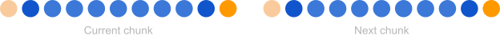

[[DRAWING]]

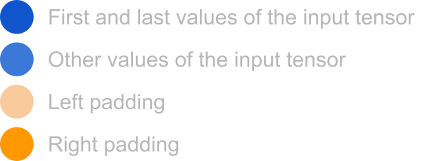

[[DRAWING]]

# Possible solutions

## Overlap-add

- Process overlapping buffers and blend them to smooth boundaries.
- This solution is compatible with any generative model.
- However, it requires redundant computations and leads to degraded quality during transition phases.
- It also requires to cache buffers that are large enough to fill the receptive field of the model.
- All of this results in high latency.

## Causal convolutions

- Use causal convolutional neural networks with cached padding as in the [Streaming keyword spotting on mobile devices](https://www.google.com/url?q=https://arxiv.org/abs/2005.06720&sa=D&source=editors&ust=1763118208390626&usg=AOvVaw1QRiMZhk9zx4ayYOMluq0c) paper.
- The idea is to put all the padding on the left side of the audio chunk (the side that corresponds to the values in the past).

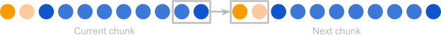

[[DRAWING]]

- Then, each audio chunk (except the first one) is padded with the end of the previous audio chunk (hence the name causal, because each chunk is padded with values from the past but is not padded with values from the future).
- This solution preserves continuity between chunks.
- However, it restricts the model architectures to causal convolutions which makes learning more complex because the model is not given access to the values in the future during training even though they are available (because training is not done in a streaming way).

# Proposed solution

- The paper proposes to perform a post-training causal reconfiguration of the model.
- This allows to consider convolutional networks trained using any type of padding (potentially non-causal) and turn them into streamable models.
- The main idea is to remove the right padding (on the future side) and replace it with an additional left padding (on the past side).
- The main challenge of such a reconfiguration is to leave the computational graph of the model unchanged.
- Indeed, depending on the configuration of each layer, the additional left padding can break the time alignment between its inputs and outputs.
- Thus, the paper proposes to keep track of the delay cumulated at each new layer and to introduce additional delays in the graph to restore the time alignment.

Below are some detailed explanations for different layer configurations.

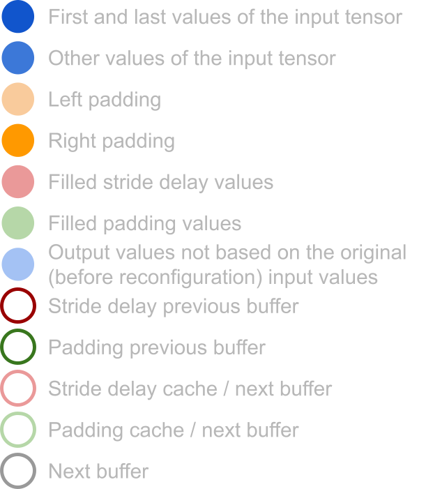

[[DRAWING]]

The figure below represents 2 convolution layers before the causal reconfiguration

- Layer 1
- Layer 2

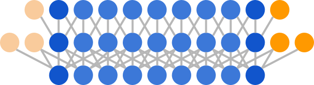

[[DRAWING]]

Let us see how the causal reconfiguration is applied to each layer.

### Layer 1

#### Reconfiguration

The reconfiguration moves the right padding to the left of the graph and thus, introduces a delay compared to the initial non causal graph.

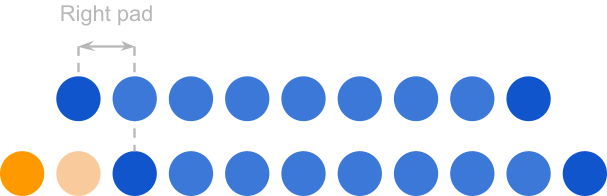

[[DRAWING]]

#### Inference

For layer 1

During inference, these 3 steps are applied:

- The left pad values are filled with the last values of the previous buffer.
- The last values of the current buffer are stored in the cache.
- And the convolution is applied.

Each step corresponds to one line in the figure below, see [here](https://www.google.com/url?q=https://github.com/acids-ircam/cached_conv/blob/v2.3.6/cached_conv/convs.py%23L119&sa=D&source=editors&ust=1763118208408554&usg=AOvVaw3kdkBXXBf9RXtSqHXe31W8) for the original implementation.

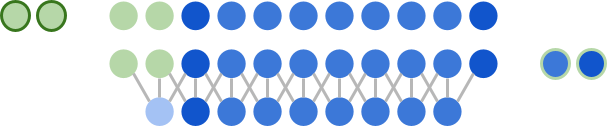

[[DRAWING]]

### Layer 2

#### Reconfiguration

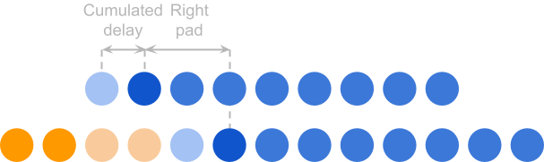

[[DRAWING]]

#### Inference

For layer 2

During inference, the same 3 steps as for layer 1 are applied.

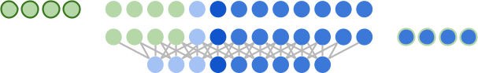

[[DRAWING]]

### Summary

Below is a summary of all the steps explained above.

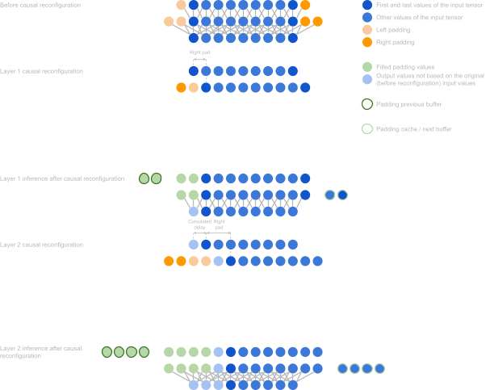

[[DRAWING]]

The figure below represents 2 convolution layers before the causal reconfiguration

- Layer 1
- Layer 2

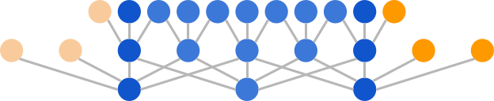

[[DRAWING]]

Let us see how the causal reconfiguration is applied to each layer.

### Layer 1

#### Reconfiguration

The reconfiguration moves the right padding to the left of the graph and thus, introduces a delay compared to the initial non causal graph.

However, as can be seen below, this delay breaks the time alignment between the layer input and the convolution stride.

This means that without additional reconfiguration, the time alignment between the layer input and output is not preserved.

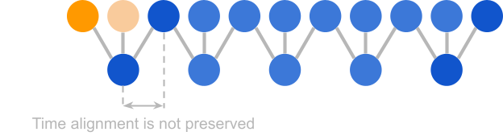

[[DRAWING]]

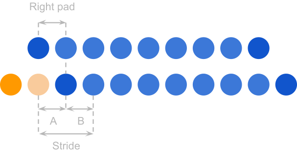

[[DRAWING]]

For layer 1

#### Inference

For layer 1

The first 3 steps handle the introduced to preserve the stride alignment while the 3 other steps handle the causal reconfiguration of the right padding as seen before.

The 6 steps are:

- The first values are filled with the last values of the previous buffer.
- The last values of the current buffer are stored in the cache.
- The resulting tensor is cropped (the last values are dropped).
- This is done to preserve the time dimensionality of the input tensor.
- The dropped values are not lost because they will be processed by the next buffer.
- However, a slight discontinuity seems to occur. See Notes on the continuity between buffers for more details.
- The left pad values are filled with the last values of the previous buffer.
- The last values of the current buffer are stored in the cache.
- And the convolution is applied.

Each step corresponds to one line in the figure below, see [here](https://www.google.com/url?q=https://github.com/acids-ircam/cached_conv/blob/v2.3.6/cached_conv/convs.py%23L119&sa=D&source=editors&ust=1763118208468266&usg=AOvVaw0NYATauxL9hpmurlVUNNtA) for the original implementation.

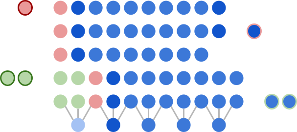

[[DRAWING]]

### Layer 2

#### Reconfiguration

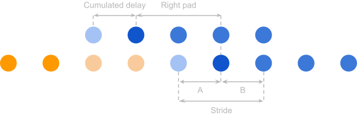

[[DRAWING]]

#### Inference

For layer 2

During inference, the same 6 steps as for layer 1 are applied.

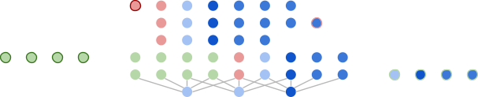

[[DRAWING]]

### Summary

Below is a summary of all the steps explained above.

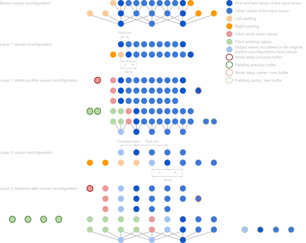

[[DRAWING]]

### Notes on the continuity between buffers

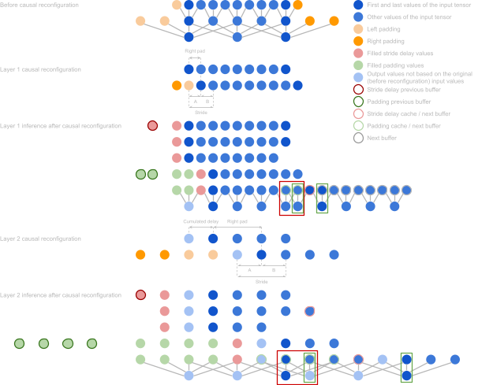

[[DRAWING]]

- Despite this possible discontinuity, the [Streamable Neural Audio Synthesis With Non-Causal Convolutions](https://www.google.com/url?q=https://arxiv.org/abs/2204.07064&sa=D&source=editors&ust=1763118208501458&usg=AOvVaw3S6S-r6MSy2AEzBDICn7oO) paper reports no difference between the outputs of the studied RAVE model before and after the causal reconfiguration (figure 8 of the paper).
- This suggests that either the discontinuity has a negligible effect on the output quality or that I have missed something and there is no such discontinuity.

## Parallel branches

Similarly the convolution layers, parallel branches in the computational graph need to be handled after the causal reconfiguration.

Indeed, each branch introduces its own delay, depending on the layers that compose it.

Before merging parallel branches, for example in the element-wise sum layer in a residual connection, all the parallel branches need to be aligned to compensate for their different individual delays.

# Sources

### Papers

- [Streamable Neural Audio Synthesis With Non-Causal Convolutions](https://www.google.com/url?q=https://arxiv.org/abs/2204.07064&sa=D&source=editors&ust=1763118208517761&usg=AOvVaw2U3xUQuR4tbj5IRx6Azq3B)
- [Streaming keyword spotting on mobile devices](https://www.google.com/url?q=https://arxiv.org/abs/2005.06720&sa=D&source=editors&ust=1763118208517972&usg=AOvVaw1VimDLXJBCtfyfkicyjgEC)

### Code

- [RAVE v1](https://www.google.com/url?q=https://github.com/acids-ircam/RAVE/tree/v1&sa=D&source=editors&ust=1763118208518187&usg=AOvVaw1GQuzYeewUyRTov8Mvis5R)
- [cached_conv v2.3.6](https://www.google.com/url?q=https://github.com/acids-ircam/cached_conv/tree/v2.3.6&sa=D&source=editors&ust=1763118208518377&usg=AOvVaw3bgIIL0dxNMqllOSXlIm3U)

Notes

# RAVE Code ([tag v1](https://www.google.com/url?q=https://github.com/acids-ircam/RAVE/tree/v1&sa=D&source=editors&ust=1763118208518644&usg=AOvVaw0ZtaB-0E332ekQKum9A5vu))

## Training

### Encoder

- Inputs: (batch, sequence, n_decomposition_bands=16)
- Outputs: (batch, sequence?, 2 x latent_size)
- [Cached convolution 1d](https://www.google.com/url?q=https://github.com/acids-ircam/cached_conv/blob/v2.3.6/cached_conv/convs.py%23L90&sa=D&source=editors&ust=1763118208519194&usg=AOvVaw1cDWYdFJd-Xz9D-NeFEoZk)
- [Padding](https://www.google.com/url?q=https://github.com/acids-ircam/RAVE/blob/v1/rave/model.py%23L445&sa=D&source=editors&ust=1763118208519348&usg=AOvVaw1d1ypMkgAnsphlJJtxOFdT)
- Parameters defined in RAVE here.
- Code implemented [here](https://www.google.com/url?q=https://github.com/acids-ircam/cached_conv/blob/v2.3.6/cached_conv/convs.py%23L7&sa=D&source=editors&ust=1763118208519609&usg=AOvVaw1Dg1nxOiaIs42NeT2qDRCT) in Cached conv.
- "causal" if no_latency else "centered".
- Default training with "centered".

### Decoder

- Inputs: (batch, sequence?, latent_size)
- Outputs: (batch, sequence?, n_decomposition_bands=16)

## Cached conv ([v2.3.6](https://www.google.com/url?q=https://github.com/acids-ircam/cached_conv/tree/v2.3.6&sa=D&source=editors&ust=1763118208520297&usg=AOvVaw0pkErBV7f4-A0sf2CfHUIu))

### [get_padding()](https://www.google.com/url?q=https://github.com/acids-ircam/cached_conv/blob/v2.3.6/cached_conv/convs.py%23L7&sa=D&source=editors&ust=1763118208520505&usg=AOvVaw1_dYSIbqcPF4K5ZzCXE_MA)

- The stride parameter has no influence !
- Dilated convolutions explanations [here](https://www.google.com/url?q=https://medium.com/data-science/types-of-convolutions-in-deep-learning-717013397f4d&sa=D&source=editors&ust=1763118208520852&usg=AOvVaw2MAz6nnb_dpocmZRwp1DZ7) and [here](https://www.google.com/url?q=https://medium.com/@akp83540/dilation-rate-in-a-convolution-operation-a7143e437654&sa=D&source=editors&ust=1763118208520974&usg=AOvVaw1DjgOsCiB5-LvUG78ul1AE).